# Targeting Vulnerable

The objective of this pilot was to see whether we could find an effective way to find the least connected nodes in a village. As these would most likely be the people who are most adversely affected due to COVID-19.

The search process was carried out as follows -

1. From an initial list of contacts (gram panchayat members and other snowballed contacts) across multiple villages in West Bengal, we randomly sampled a few villages and selected one individual from each village to be the “first point of contact”.
2. “First contacts” were then phoned by enumerators who ran a short survey with them. We also randomised a “nomination” question in the first contact survey, so **first contacts were either asked to nominate a “gossip” in their village, or the “person with the maximum degree” (person who knew the most number of people in the village)**.
3. The “gossips” and the “max degree” individuals were then surveyed and were asked to nominate– **1. disconnected/vulnerable people in their village, who would probably be most affected by covid-19 as a result of not having many contacts.** 2. Others in their village who were as connected as they were, but who did not know many of the gossip’s/max degree’s contacts, or who had many contacts that the gossip/max degree did not know (henceforth called ‘RDS gossips’).
4. ‘RDS gossips’ were also contacted and asked to nominate disconnected/vulnerable people from their village.
5. **We also phoned the ASHA workers that were working in the same village as the gossips/max degree’s/RDS gossips and asked them to nominate vulnerable/disconnected individuals as well**.
6. All the “disconnected” nominees from the gossips/max degree individuals/RDS gossips and ASHA workers were surveyed separately, we asked them about their level of ‘connectedness’ in the village and their usage of the PDS system, as well as other services.

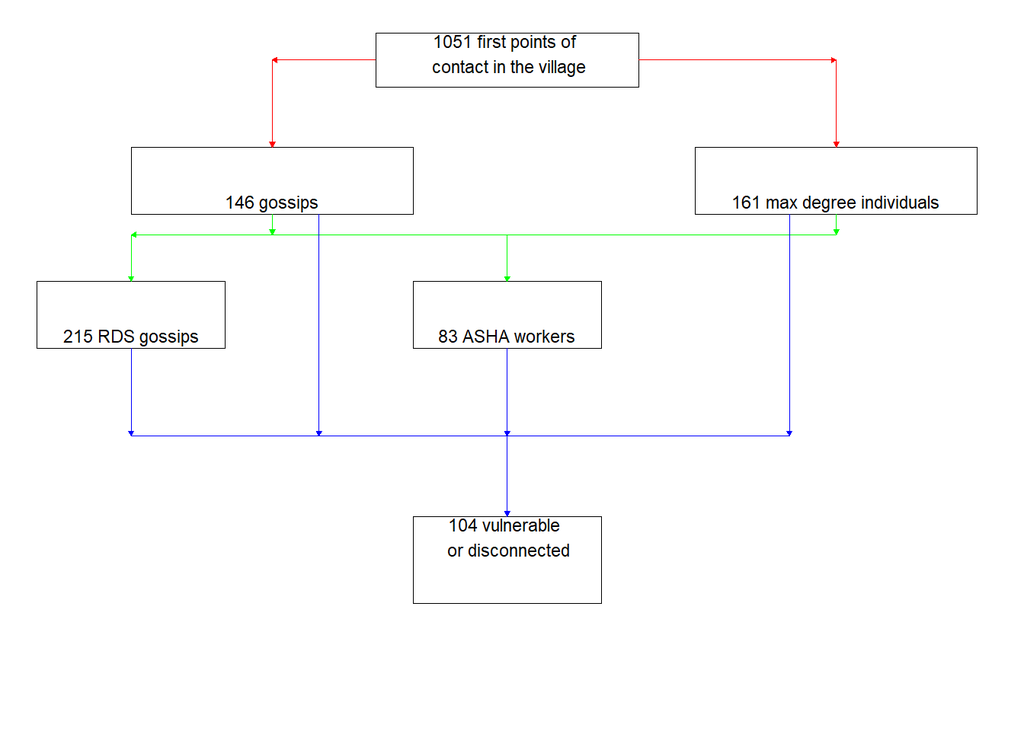

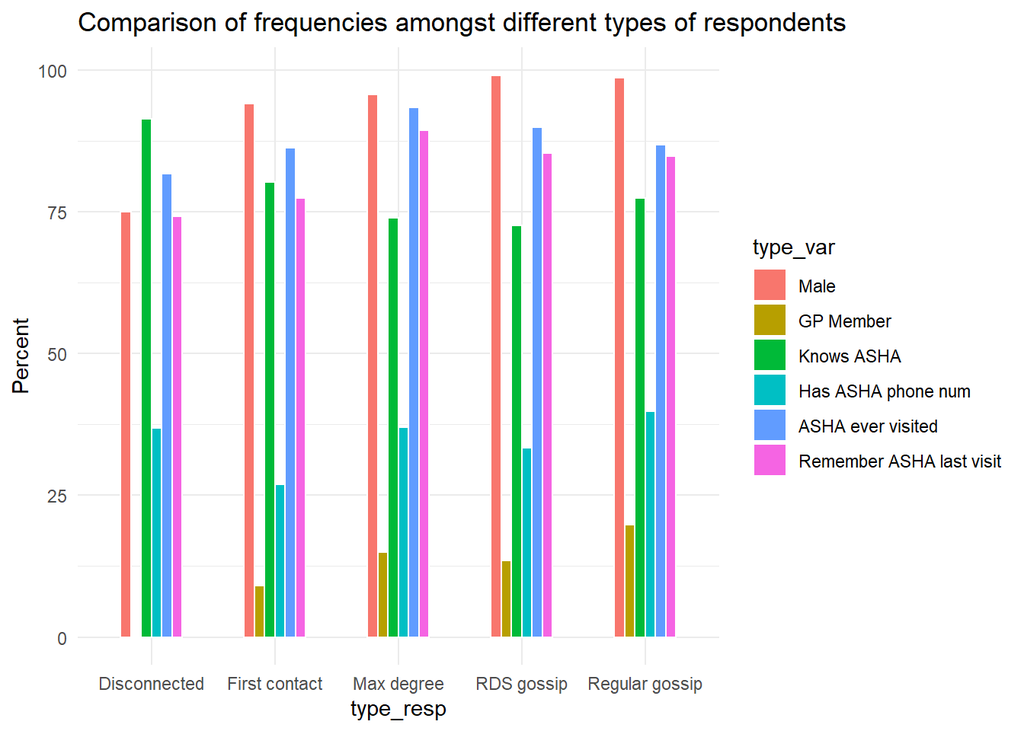

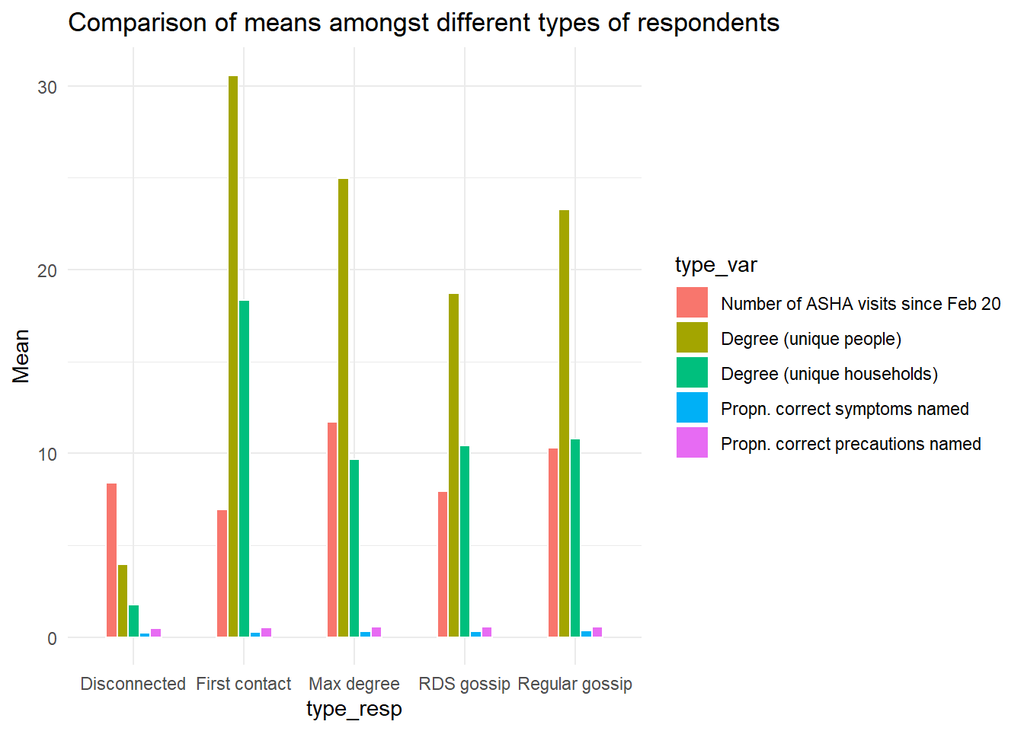

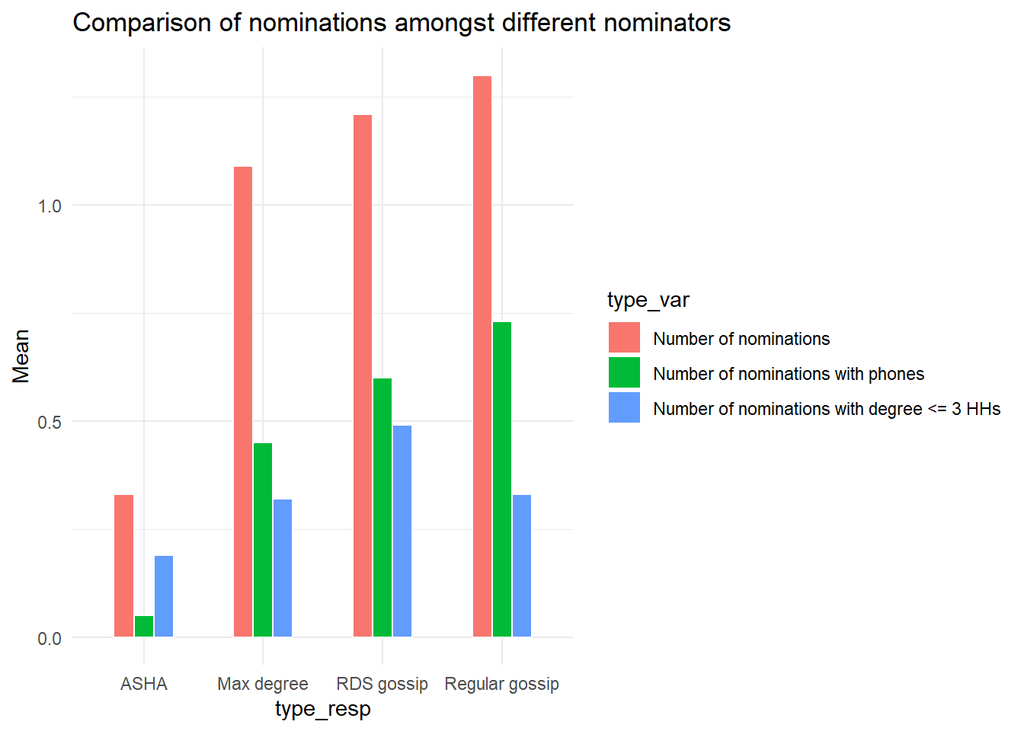

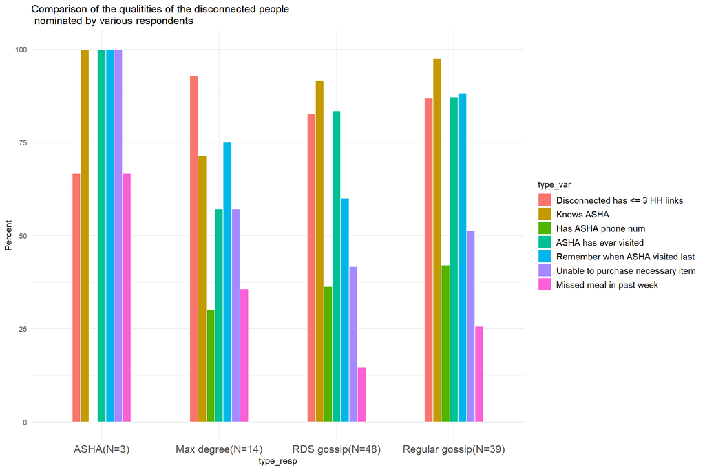

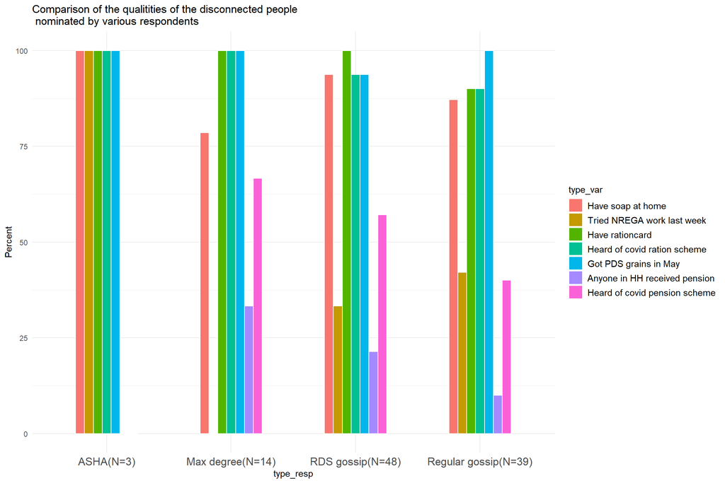

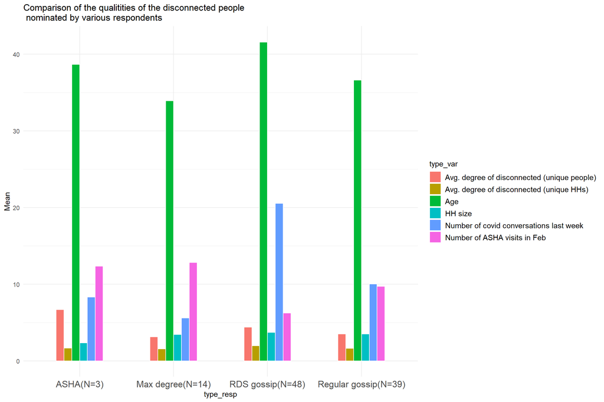

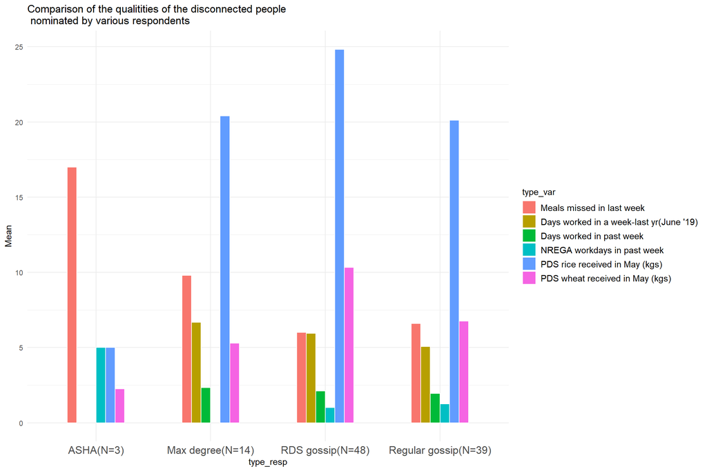